# Les sources de l’information géographique

Nicolas Lambert, Timothée Giraud, Matthieu Viry, Ronan Ysebaert

Dernière modification : septembre 2025

## Les composantes de l’IG

[interactive chart not shown]

# Géométries

## Géométries

Elles définissent la **forme** et la **localisation** de l’objet à cartographier sur la surface terrestre.

La position des géométries est toujours exprimée dans un système de coordonnées explicite : **coordonnées géographiques** (latitude / longitude) ou **coordonnées projetées** (X / Y).

[figure not shown]

## Vecteurs et rasters

2 types de données sont à différencier : le raster et le vecteur.

### Raster

C’est une **image** (plan scanné, photographie aérienne, image satellitaire…) **localisée dans l’espace**.

L’information géographique est alors stockée dans des cellules (pixel) contiguës généralement carrées.

Chaque pixel **défini par une résolution** possède des valeurs qui peuvent être traitées et cartographiées.

Leur manipulation et analyse relève de champs méthodologiques particuliers (télédétection). Les logiciels de cartographie thématique ne sont pas adaptés à leur manipulation (> SIG).

[figure not shown]

## Vecteurs et rasters

2 types de données sont à différencier : le raster et le vecteur.

### Vecteur

Il s’agit d’objets géométriques de type **points**, **lignes** ou **polygones**.

Ces objets vectoriels ne **pixellisent pas**. On parlera néanmoins de niveaux de généralisation pour qualifier leur niveau de précision (parfois aussi appelée résolution).

Chaque objet est défini par **un identifiant unique**.

[figure not shown]

## Vecteurs et rasters

2 types de données sont à différencier : le raster et le vecteur.

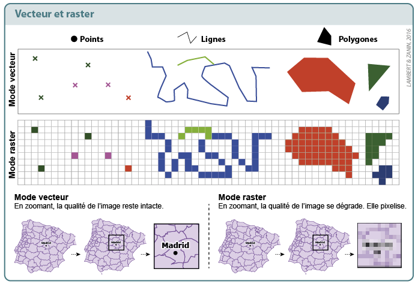

## Formats de fichiers vectoriels

Les formats de stockage des géométries les plus connus sont :

- **Shapefile (.shp)** : ou « fichier de formes » est le format de fichier **historique** des SIG. Initialement développé par ESRI pour ses logiciels commerciaux, il est devenu un standard *de facto*, malgré ses limitations (taille de fichiers, longueur texte, nombre maximal d’attributs)…
- **Geographic JSON (.geojson)** : Un format ouvert d’encodage de données géospatiales utilisant la norme JSON (JavaScript Object Notation), assez répandu sur le Web (cartographie interactive, D3.js).
- **GeoPackage (.gpkg)** : Un format de données géospatiales raster ou vecteur, ouvert, non lié à un système d’exploitation. Conçu pour être aussi léger que possible, il permet notamment de stocker plusieurs couches géographiques dans un seul et même fichier.
- **Keyhole Markup Language (.kml)** : ou « langage à base de balises géolocales », est fondé sur le formalisme XML. Depuis 2008, le format est normalisé par l’Open Geospatial Consortium. Il s’agit, avec le .gpx, du format classique de données produites par GPS.
- **Fichiers tabulaires (.csv, .xls, etc.)** : tout simplement ! A partir du moment où ils contiennent une dimension géographique (localisation X/Y relative à un point en général).

## Le shapefile

Son extension est classiquement **.shp**, mais il est toujours accompagné de deux autres fichiers de même nom :

- **.dbf** : contient les données attributaires.
- **.shx** : stocke l’index de la géométrie.

D’autres fichiers peuvent optionnellement être également fournis :

- **.sbn et .sbx**: index spatial des formes.
- **.prj** : information sur le système de coordonnées.
- **.shp.xml** : métadonnées du shapefile.
- **.cpg** : gestion de l’encodage.
- et potentiellement d’autres : .fbn, .fbx, .atx…

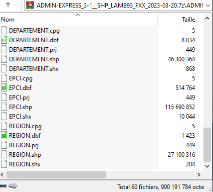

> Il faut toujours conserver l’intégrité de l’ensemble de ces fichiers et ne jamais éditer un fichier en dehors de logiciels dédiés.

## Niveaux de généralisation

Le niveau de détail relatif aux géometries vectorielles (nombre de points).

Les fournisseurs de données géographiques fournissent régulièrement plusieurs niveaux de généralisation, comme **Eurostat (GISCO)**.

- 1:1 Million
- 1:3 Million
- 1:10 Million
- 1:20 Million
- 1:60 Million

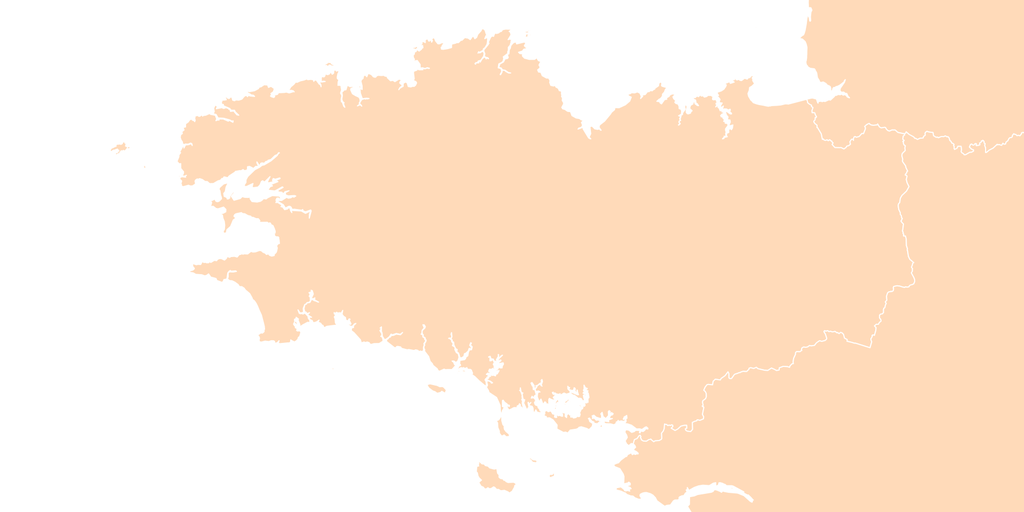

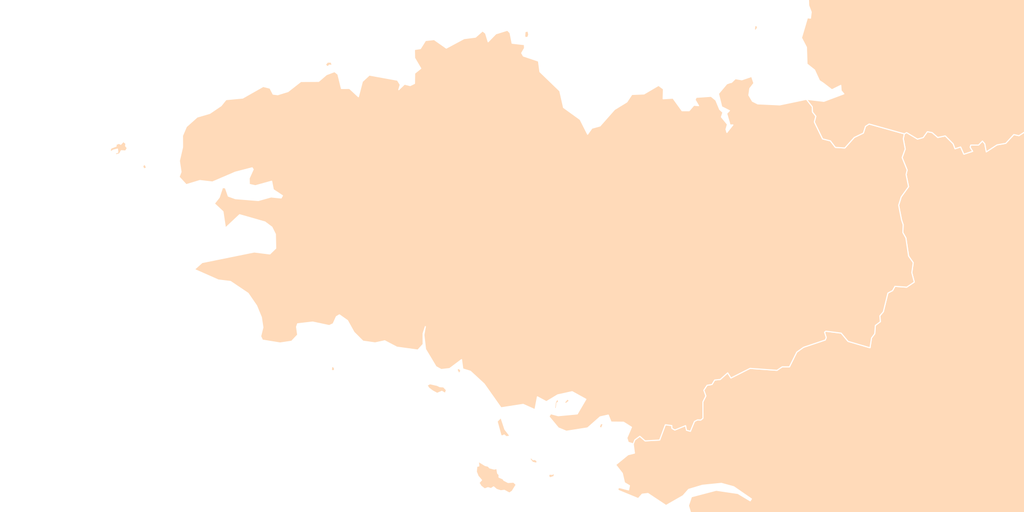

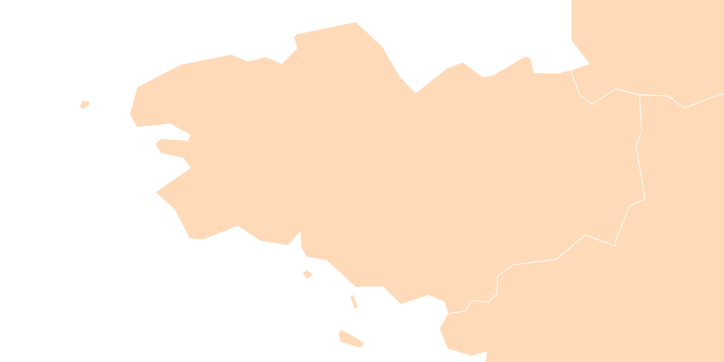

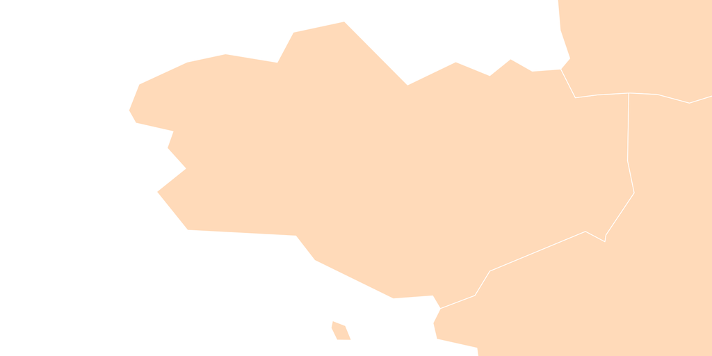

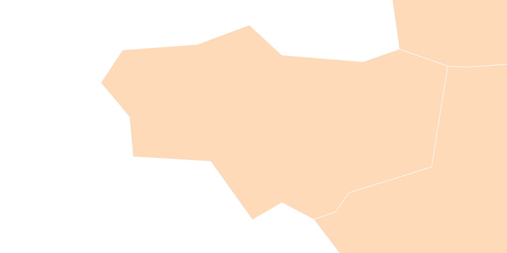

## Niveaux de généralisation

Le niveau de détail relatif aux géometries vectorielles (nombre de points).

Les fournisseurs de données géographiques fournissent régulièrement plusieurs niveaux de généralisation, comme **Eurostat (GISCO)** ou **Natural Earth**.

- 10 (large)
- 50 (medium)
- 110 (small)

## Niveaux de généralisation

Le choix du niveau de généralisation adapté dépend des **objectifs de la carte**, de l’emprise de **espace d’étude**, et des **caractéristiques des polygones du fond de carte**.

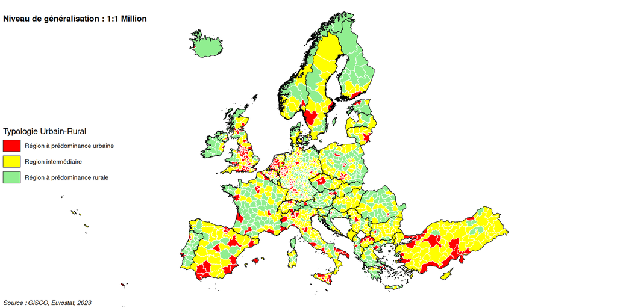

## Niveaux de généralisation

Le choix du niveau de généralisation adapté dépend des **objectifs de la carte**, de l’emprise de **espace d’étude**, et des **caractéristiques des polygones du fond de carte**.

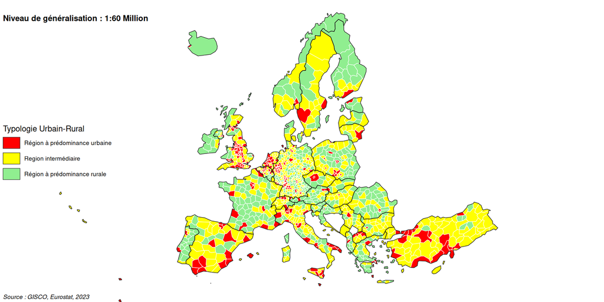

## Simplifier les géométries

Des outils existent pour simplifier le niveau de détail des géométries, comme [Mapshapper](https://mapshaper.org/)

[figure not shown]

[figure not shown]

## Rechercher de l’information géographique

Les fournisseurs de fonds de carte géoréférencés sont nombreux…

**En France, un incontournable : l’IGN**

- [Géoservices de l’IGN (Institut National de l’information géographique et forestière)](https://geoservices.ign.fr/telechargement)
- [Géoportail (portail national d’accès à l’information géographique de référence)](https://www.geoportail.gouv.fr/)

**Les organismes “spécialisés”**

- [Bureau de Recherches Géologiques et Minières (BRGM)](http://infoterre.brgm.fr)
- [Agence de l’Environnement et de la Maîtrise de l’Energie (ADEME)](https://data.ademe.fr/)
- [Office national des forêts](https://www.onf.fr/onf/connaitre-lonf/+/35::open-data-pour-mieux-partager-les-donnees-forestieres.html)
- …

**Les collectivités territoriales**

- Portail Open Data des régions : [Ile-de-France](https://data.iledefrance.fr/pages/home/%22), [Hauts-de-France](https://opendata.hautsdefrance.fr/), [Bretagne](https://data.bretagne.bzh/pages/home-page/) etc.
- Portail Open Data des métropoles : [Métropole du Grand Paris](https://metropole-grand-paris.opendata.arcgis.com/), [Métropole Européenne de Lille](https://opendata.lillemetropole.fr/page/home/), [Rennes Métropole](https://data.rennesmetropole.fr/explore/?sort=modified), etc.

**Au niveau international**

- [Eurostat - GISCO](https://ec.europa.eu/eurostat/web/gisco/geodata/reference-data)
- [Copernicus](https://land.copernicus.eu/)
- [Natural Earth](https://www.naturalearthdata.com/)
- [World Pop](https://www.worldpop.org/)
- [Global Administrative Boundaries (GADM)](https://gadm.org/)
- [OpenSreetMap (OSM)](https://www.openstreetmap.fr/), données exportables via des API comme [Overpass-turbo](http://overpass-turbo.eu/)

# Enrichir les géométries par des données statistiques

## Données attributaires ?

L’ensemble des informations relatives à un objet géographique, qui le décrivent et le caractérisent.

[figure not shown]

## Pourquoi faire ?

Les géométries contiennent souvent quelques attributs statistiques, **assez limités** pour initier des analyses ou produire des représentations cartographiques.

Attributs associés aux géométries des communes françaises (IGN)

```
                        ID                   NOM                 NOM_M
1 COMMUNE_0000002324290054            Culoz-Béon            CULOZ-BEON
2 COMMUNE_0000000009751205                 Pizay                 PIZAY
3 COMMUNE_0000000009750692 L'Abergement-de-Varey L'ABERGEMENT-DE-VAREY
4 COMMUNE_0000000009750946    Châtillon-la-Palud    CHATILLON-LA-PALUD
5 COMMUNE_0000000009749292                   Gex                   GEX
  INSEE_COM          STATUT POPULATION INSEE_CAN INSEE_ARR INSEE_DEP INSEE_REG
1      1138  Commune simple       3426        10         1         1        84
2      1297  Commune simple        890        12         2         1        84
3      1002  Commune simple        262         1         1         1        84
4      1092  Commune simple       1622         7         2         1        84
5      1173 Sous-préfecture      13177         9         3         1        84
  SIREN_EPCI
1  200040350
2  240100610
3  240100883
4  200069193
5  240100750
```

Attributs associés aux géométries des régions européennes (GISCO)

```
    LEVL_CODE NUTS_ID URBN_TYPE CNTR_CODE             NAME_LATN
131         2    FR10         0        FR         Ile-de-France
132         2    FRB0         0        FR Centre - Val de Loire
133         2    FRC1         0        FR             Bourgogne
134         2    FRC2         0        FR         Franche-Comté
135         2    FRD1         0        FR       Basse-Normandie
136         2    FRD2         0        FR       Haute-Normandie
                NUTS_NAME MOUNT_TYPE COAST_TYPE  geo
131         Ile-de-France          0          0 FR10
132 Centre - Val de Loire          0          0 FRB0
133             Bourgogne          0          0 FRC1
134         Franche-Comté          0          0 FRC2
135       Basse-Normandie          0          0 FRD1
136       Haute-Normandie          0          0 FRD2
```

## Pourquoi faire ?

Les géométries contiennent souvent quelques attributs statistiques, **assez limités** pour initier des analyses ou produire des représentations cartographiques.

Attributs associés aux géométries pays du monde (Natural Earth)

```
       featurecla scalerank LABELRANK                  SOVEREIGNT SOV_A3
1 Admin-0 country         1         6                        Fiji    FJI
2 Admin-0 country         1         3 United Republic of Tanzania    TZA
3 Admin-0 country         1         7              Western Sahara    SAH
4 Admin-0 country         1         2                      Canada    CAN
5 Admin-0 country         1         2    United States of America    US1
6 Admin-0 country         1         3                  Kazakhstan    KA1
  ADM0_DIF LEVEL              TYPE TLC                       ADMIN ADM0_A3
1        0     2 Sovereign country   1                        Fiji     FJI
2        0     2 Sovereign country   1 United Republic of Tanzania     TZA
3        0     2     Indeterminate   1              Western Sahara     SAH
4        0     2 Sovereign country   1                      Canada     CAN
5        1     2           Country   1    United States of America     USA
6        1     1       Sovereignty   1                  Kazakhstan     KAZ
  GEOU_DIF                  GEOUNIT GU_A3 SU_DIF        SUBUNIT SU_A3 BRK_DIFF
```

[output cut: 202 more lines]

## Dimension géographique de tableaux de données statistiques

On parle ici de tableaux de données définis par :

- Une emprise géographique (France, Europe, Monde, etc.)
- Une brique géographique élémentaire (une commune, une rivière, une région, une forêt, etc.)
- Des données attributaires utiles à l’analyse.
- Un identifiant unique pour chaque brique géographique élémentaire.
- Une correspondance au moins partielle avec le fond de carte dont on dispose.

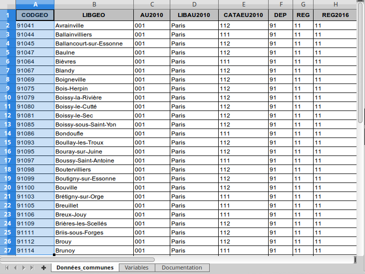

> On peut alors enrichir sémantiquement les géométries !

## Comment faire ?

Dans les cas relevant de la donnée institutionnelle c’est plutôt facile ! Les codes géographiques (uniques) des unités territoriales qui composent les fonds de carte sont normés et une association étroite entre fond de carte.

On peut citer par exemple :

- A l’**échelle mondiale** : Natural Earth (géométries) / Nations Unies (Population prospect) : pays définis par des codes ISO uniques.
- A l’**échelle européenne** : GISCO (géométries) / Eurostat (données socio-économiques). Régions européennes définies par la nomenclature **NUTS**.
- A l’**échelle française** : IGN (géométries) / INSEE. Plusieurs découpages disponibles (communes, EPCI, etc.)

Il faut juste veiller à la **compatibilité de version des données et géométries**

Données de population communales de l’INSEE

[figure not shown]

## Comment faire ?

Dans les cas relevant de la donnée institutionnelle c’est plutôt facile ! Les codes géographiques (uniques) des unités territoriales qui composent les fonds de carte sont normés et une association étroite entre fond de carte.

On peut citer par exemple :

- A l’**échelle mondiale** : Natural Earth (géométries) / Nations Unies (Population prospect) : pays définis par des codes ISO uniques.
- A l’**échelle européenne** : GISCO (géométries) / Eurostat (données socio-économiques). Régions européennes définies par la nomenclature **NUTS**.
- A l’**échelle française** : IGN (géométries) / INSEE. Plusieurs découpages disponibles (communes, EPCI, etc.)

Il faut juste veiller à la **compatibilité de version des données et géométries**

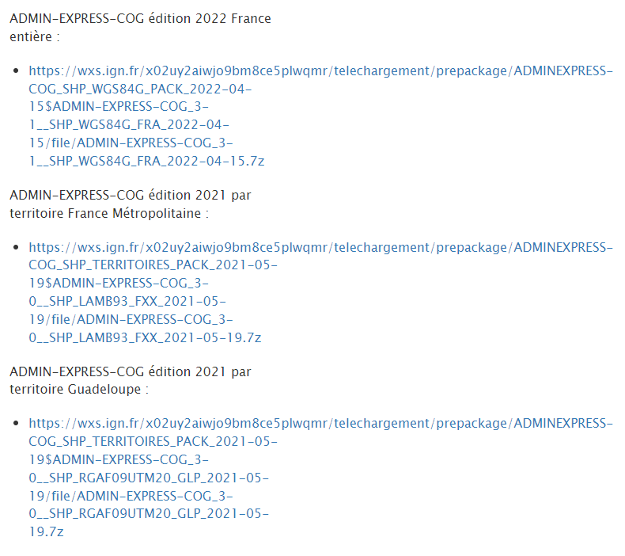

## Comment faire ?

Pour les fonds de carte “moins conventionnels”, utiliser les fonctionnalités des SIG ou des logiciels de cartographie thématique pour exporter les codes associés et gérer la bonne concordance entre les données que vous collectez et les fonds de carte de référence.

[figure not shown]

## Comment faire ?

L’enrichissement de données attributaires au format tabulaire (.csv, .xls, .ods, etc.) est réalisé par une **jointure attributaire**.

Elle d’**associer deux tables attributaires décrivant des entités communes**. L’opération produit une seule table juxtaposant les champs de la table à joindre à ceux de la table d’origine.

Avec les logiciels de cartographie / SIG, la table d’origine est souvent associée aux géométries.

Les jointures attributaires sont utilisées pour introduire des informations nouvelles dans une couche géographique.

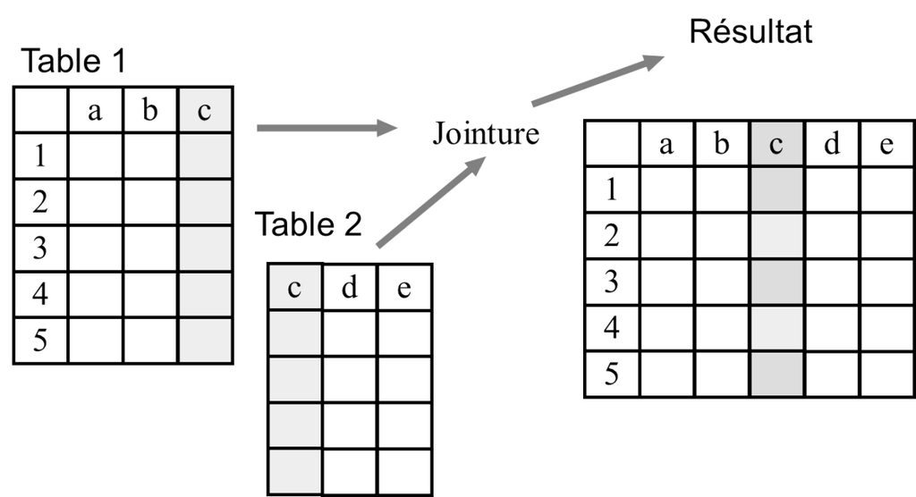

Source : Université Virtuelle Environnement et Développement durable, glossaire des SIG

## Comment faire ?

La jointure attributaire est une fonctionnalité de base des logiciels de cartographie thématique ou de SIG.

[figure not shown]

[figure not shown]

## Pour conclure…

**Questions centrales à se poser lorsque l’on recherche de l’information géographique**

- **Quel est mon espace d’étude ?** *Monde ? Europe ? France ? Ile-de-France ? …*
- **Quel est l’objet géographique sur lequel je travaille ?** *Pays ? Régions ? Communes ? Parcs naturels ? Rivières ? …*
- **Quelle est la thématique que je souhaite explorer ?** *Environnement ? Démographie ? Transport? …*
- **Quel est le format de données que je recherche ?** *Géométries ? Données statistiques à joindre à mes couches géographiques ?*
- **Données institutionnelles ? Quelle période ?**